# Assignment 08

Nicola Hallmann

2024-05-03

# Task

Download (a subset of) ATAC-seq peak counts in the hippocampus upon stress (already in SummarizedExperiment format): https://ethz-ins.org/content/mouse_mm38_hippocampus.peakCounts.SE.rds

- (the data is from the mouse ensembl GRCm38 genome – you should already have the genome, e.g. from week 6)
- Using this object
  - perform a chromVAR motif analysis, and
  - run 2 differential motif accessibility analyses, respectively:
    - comparing stressed (denoted ‘FSS’ – forced swim stress) and control animals
    - comparing male and female animals
- For each analysis,
  - report the top most significant motifs
  - plot a heatmap of the normalized accessibility scores across the samples for those motifs
  - write a short paragraph interpreting the results

```r
suppressPackageStartupMessages({
  library(ensembldb)
  library(epiwraps)
  library(motifmatchr)
  library(MotifDb)
  library(universalmotif)
  library(ggplot2)
  library(SummarizedExperiment) # data structure
  library(sechm) # for plotting heatmaps from a SummrizedExperiment
  library(BiocParallel) # for multithreading
  library(chromVAR) # for motif accessibility estimation
  library(limma) # for statistical analysis
  library(AnnotationHub)
})
```

```
## See system.file("LICENSE", package="MotifDb") for use restrictions.
```

```r
# to control multithreading, unix users can use:
# register(MulticoreParam(4))
# for windows users, rather one of the following:
# register(SerialParam())
register(SnowParam(3))
```

```r
ah <- AnnotationHub(localHub = TRUE)
```

```
## Using 'localHub=TRUE'
##   If offline, please also see BiocManager vignette section on offline use
```

```r
AnnotationHub::query(ah, c("Mus Musculus", "GRCm38"))
```

```
## AnnotationHub with 3 records
## # snapshotDate(): 2024-04-02
## # $dataprovider: Ensembl
## # $species: Mus musculus, mus musculus
## # $rdataclass: TwoBitFile, EnsDb
## # additional mcols(): taxonomyid, genome, description,
## #   coordinate_1_based, maintainer, rdatadateadded, preparerclass, tags,
## #   rdatapath, sourceurl, sourcetype
## # retrieve records with, e.g., 'object[["AH68356"]]'
##
##             title
##   AH68356 | Mus_musculus.GRCm38.dna.primary_assembly.2bit
##   AH88477 | Mus_musculus.GRCm38.dna_sm.primary_assembly.2bit
##   AH89211 | Ensembl 102 EnsDb for Mus musculus
```

```r
GRCm38_genome <- ah[["AH68356"]]
```

```
## loading from cache
```

```
## require("rtracklayer")
```

```r
# we'll load it into memory:
genome_seqs <- import(GRCm38_genome)
# if the genome was a fasta file instead, import using Biostrings::readDNAStringSet()
#ensdb <- ah[["AH89211"]] # mouse ensembldb object
```

```r
# Download (a subset of) ATAC-seq peak counts in the hippocampus upon stress (already in SummarizedExperiment format)
download.file("https://ethz-ins.org/content/mouse_mm38_hippocampus.peakCounts.SE.rds", "mouse_m38_hippocampus.peakCounts.SE.rds")
hippoc_se <- readRDS("mouse_m38_hippocampus.peakCounts.SE.rds")
```

motif database

```r
motifs <- MotifDb::query(MotifDb, c("mus", "HOCOMOCOv10"))
# convert to a format motifmatchr can use, and use the gene symbols as names
motifs <- do.call(TFBSTools::PWMatrixList, setNames(
  universalmotif::convert_motifs(motifs, class="TFBSTools-PWMatrix"), mcols(motifs)$geneSymbol))
```

```r
colnames(hippoc_se) # get the names of the assays to identify control/FSS and m/f
```

```
##  [1] "Control_female_GSM6041841.bam" "Control_female_GSM6041842.bam"
##  [3] "Control_female_GSM6041843.bam" "Control_male_GSM6041844.bam"
##  [5] "Control_male_GSM6041845.bam"   "Control_male_GSM6041846.bam"
##  [7] "FSS_female_GSM6041853.bam"     "FSS_female_GSM6041854.bam"
##  [9] "FSS_female_GSM6041855.bam"     "FSS_male_GSM6041856.bam"
## [11] "FSS_male_GSM6041857.bam"       "FSS_male_GSM6041858.bam"
```

```r
# add to colData
hippoc_se$sex <- c("f", "f", "f", "m", "m", "m", "f", "f", "f", "m", "m", "m")
hippoc_se$condition <- c("ctrl", "ctrl", "ctrl", "ctrl", "ctrl", "ctrl", "FSS", "FSS", "FSS", "FSS", "FSS", "FSS")
colData(hippoc_se)
```

```
## DataFrame with 12 rows and 3 columns
##                                   depth         sex   condition
##                               <numeric> <character> <character>
## Control_female_GSM6041841.bam  73170149           f        ctrl
## Control_female_GSM6041842.bam  93995034           f        ctrl
## Control_female_GSM6041843.bam  40167775           f        ctrl
## Control_male_GSM6041844.bam    70491005           m        ctrl
## Control_male_GSM6041845.bam    84985977           m        ctrl
## ...                                 ...         ...         ...
## FSS_female_GSM6041854.bam      73674456           f         FSS
## FSS_female_GSM6041855.bam      49285912           f         FSS
## FSS_male_GSM6041856.bam        82385764           m         FSS
## FSS_male_GSM6041857.bam        68623011           m         FSS
## FSS_male_GSM6041858.bam        81801232           m         FSS
```

```r
# add CG content of peaks to
hippoc_se <- chromVAR::addGCBias(hippoc_se, genome = genome_seqs)

# we find which peaks contain which motifs
motifs_in_peaks <- motifmatchr::matchMotifs(motifs, subject = hippoc_se, genome = genome_seqs)
```

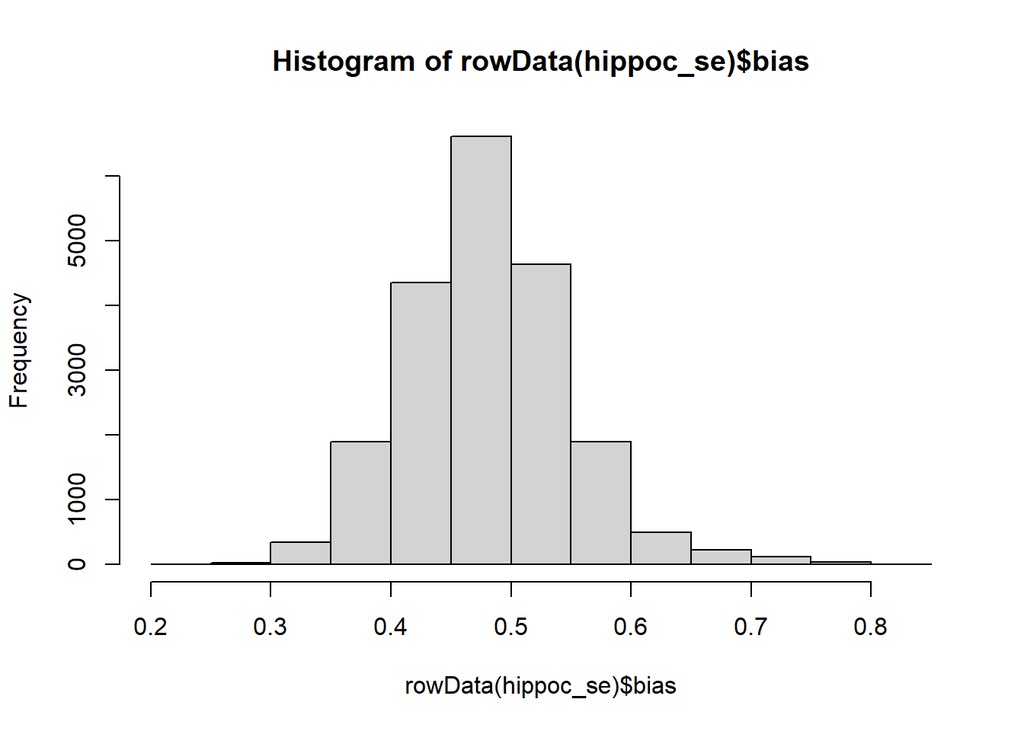

```r
hist(rowData(hippoc_se)$bias)
```

```r
# for each peak, we identify similar peaks as background
# this is a non-deterministic step - to be fully reproducible need a seed
set.seed(1234)
background <- chromVAR::getBackgroundPeaks(object = as.matrix(assays(hippoc_se)$counts), niterations=1000, bias = rowData(hippoc_se)$bias)

# for each motif, we computed per-sample deviations relative to the background
deviation <- chromVAR::computeDeviations(object = as.matrix(assays(hippoc_se)$counts), annotations = as.matrix(assay(motifs_in_peaks)), background_peaks = background)

# dev
head(assays(deviation)$z)
```

```
##      Control_female_GSM6041841.bam Control_female_GSM6041842.bam
## MUSC                   -0.61115094                    -1.1837554
## AHR                    -0.50659584                     0.2159639
## AIRE                    0.01028872                    -0.4561755
## ALX1                    0.61932245                     0.2406854
## ANDR                   -5.76150957                    -2.1154739
## AP2A                    0.35398328                    -2.0562756
##      Control_female_GSM6041843.bam Control_male_GSM6041844.bam
## MUSC                     2.3414428                  -2.6983503
## AHR                      0.3481372                  -0.2691159
## AIRE                    -2.2840452                   1.9842306
## ALX1                    -0.2436873                  -0.3689763
## ANDR                    -1.3948182                  -2.5727240
## AP2A                    -0.3345130                   2.0879424
##      Control_male_GSM6041845.bam Control_male_GSM6041846.bam
## MUSC                 -1.39902954                 -2.44250111
## AHR                   0.62613933                 -0.63979786
## AIRE                  0.02748892                 -0.23132953
## ALX1                  0.44020475                 -1.32533600
## ANDR                 -3.52006074                 -4.51402308
## AP2A                  1.64407977                 -0.02976229
##      FSS_female_GSM6041853.bam FSS_female_GSM6041854.bam
## MUSC                 1.1592519                 2.1969382
## AHR                  0.8377984                -0.2973604
## AIRE                 1.0277536                 1.3034413
## ALX1                -0.6617742                 0.8408855
## ANDR                 7.2708446                 0.1373621
## AP2A                 1.1892514                -1.8310634
##      FSS_female_GSM6041855.bam FSS_male_GSM6041856.bam FSS_male_GSM6041857.bam
## MUSC                -1.0737383              -1.7310261              -1.6049013
## AHR                 -1.3016134              -1.0236207               0.5577613
## AIRE                 0.6523562               1.5631329               1.4825952
## ALX1                 0.1585570               0.6876975              -0.3434819
## ANDR                 6.1124670               4.5830388               5.9649552
## AP2A                 0.4201151               0.6239218               1.1284650
##      FSS_male_GSM6041858.bam
## MUSC             -2.65716605
## AHR               0.03192165
## AIRE              0.25655831
## ALX1             -0.36188069
## ANDR              4.98886956
## AP2A             -0.12908790
```

```r
deviation$sex <- c("f", "f", "f", "m", "m", "m", "f", "f", "f", "m", "m", "m")
deviation$condition <- c("ctrl", "ctrl", "ctrl", "ctrl", "ctrl", "ctrl", "FSS", "FSS", "FSS", "FSS", "FSS", "FSS")
```

```r
deviation$condition
```

```
##  [1] "ctrl" "ctrl" "ctrl" "ctrl" "ctrl" "ctrl" "FSS"  "FSS"  "FSS"  "FSS"
## [11] "FSS"  "FSS"
```

```r
hippoc_se
```

```
## class: RangedSummarizedExperiment
## dim: 20660 12
## metadata(0):
## assays(1): counts
## rownames: NULL
## rowData names(1): bias
## colnames(12): Control_female_GSM6041841.bam
##   Control_female_GSM6041842.bam ... FSS_male_GSM6041857.bam
##   FSS_male_GSM6041858.bam
## colData names(3): depth sex condition
```

## differential motif accessibility analyses

### comparing stressed (denoted ‘FSS’ – forced swim stress) and control animals

```r
deviation$condition
```

```
##  [1] "ctrl" "ctrl" "ctrl" "ctrl" "ctrl" "ctrl" "FSS"  "FSS"  "FSS"  "FSS"
## [11] "FSS"  "FSS"
```

```r
deviation$condition <- factor(deviation$condition)
deviation$condition <- relevel(deviation$condition, "ctrl")
mm_ctrl <- model.matrix(~deviation$condition)
# equivalent:
#mm_ctrl <- model.matrix(~condition, data = as.data.frame(colData(deviation)))
mm_ctrl
```

```
##    (Intercept) deviation$conditionFSS
## 1            1                      0
## 2            1                      0
## 3            1                      0
## 4            1                      0
## 5            1                      0
## 6            1                      0
## 7            1                      1
## 8            1                      1
## 9            1                      1
## 10           1                      1
## 11           1                      1
## 12           1                      1
## attr(,"assign")
## [1] 0 1
## attr(,"contrasts")
## attr(,"contrasts")$`deviation$condition`
## [1] "contr.treatment"
```

Differential motif accessibility analysis comparing the FSS condition to the control condition, extract significant motifs, and visualize the results in a scatter plot.

```r
# fit a linear model to the motif accessibility scores stored in the deviation object
# The design matrix mm_ctrl is used to specify the experimental conditions
# The eBayes function applies empirical Bayes moderation to the fitted model, resulting in a moderated linear model object stored in fit_ctrl.
fit_ctrl <- eBayes(lmFit(assays(deviation)$z, mm_ctrl))
fit_ctrl
```

[output not shown]

[output cut: 82 more lines]

```
##      (Intercept) deviation$conditionFSS
## MUSC   -4.465216              -6.073393
## AHR    -4.869262              -6.104867
## AIRE   -4.846277              -4.672921
## ALX1   -4.854644              -6.104341
## ANDR   -2.831158               4.545262
## 422 more rows ...
##
## $F
## [1]  1.37230928  0.12866731  2.48091145  0.04599167 27.75243763
## 422 more elements ...
##
## $F.p.value
## [1] 2.851861e-01 8.802801e-01 1.191146e-01 9.551916e-01 1.242939e-05
## 422 more elements ...
```

```r
# extract results from the moderated linear model object fit_ctrl using the topTable function.
# coef argument specifies the contrast coefficient of interest (FSS vs. ctrl)
# The number argument specifies the number of top results to extract (here: all).
# The extracted results are stored in a data frame called res_ctrl.
res_ctrl <- as.data.frame(topTable(fit_ctrl, coef="deviation$conditionFSS", number = Inf))
head(res_ctrl)
```

```
##       ID    logFC    AveExpr        t      P.Value   adj.P.Val         B
## 5   ANDR 8.156024 0.76491065 7.322462 3.478350e-06 0.001485255  4.545262
## 125  GCR 5.420438 0.83359684 5.345162 9.852998e-05 0.021036152  1.575285
## 308 PRGR 3.766787 0.08224651 3.906769 1.542118e-03 0.219494852 -0.957963
## 213 MSX2 1.888558 0.27719475 2.979659 9.819244e-03 0.996928772 -2.666184
## 126  GCR 1.926270 0.08391172 2.625585 1.977722e-02 0.996928772 -3.303005
## 309 PRGR 1.926270 0.08391172 2.625585 1.977722e-02 0.996928772 -3.303005
```

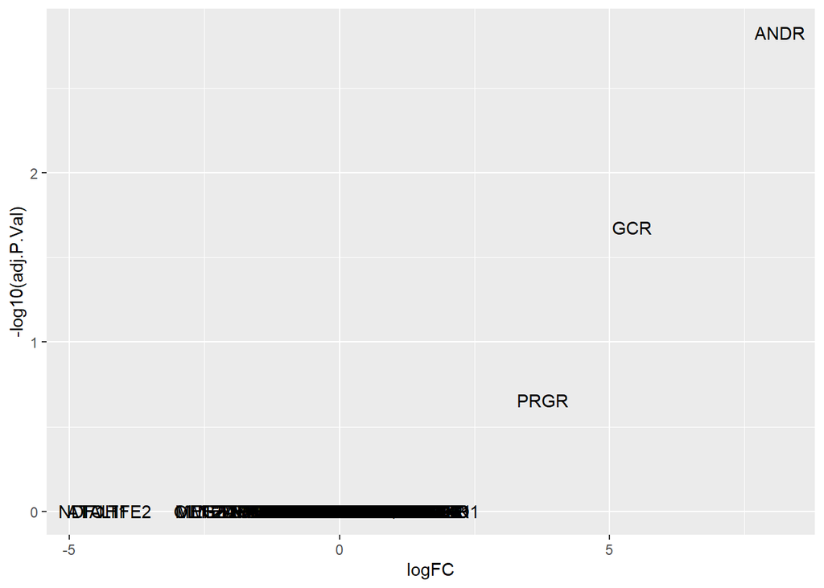

```r
# create a scatter plot - logFC on x-axis vs. -log10(adj.P.Val) on y-axis.
# Each point on the plot represents a TF motif, their names are labeled on the plot using geom_text().
ggplot(res_ctrl, aes(logFC, -log10(adj.P.Val), label = ID)) + geom_text()
```

```r
# report the top most significant motifs
# Filter motifs based on adjusted p-value <= 0.05
sig_motifs_ctrl <- res_ctrl[res_ctrl$adj.P.Val <= 0.05, ]
print(sig_motifs_ctrl)
```

```
##       ID    logFC   AveExpr        t      P.Value   adj.P.Val        B
## 5   ANDR 8.156024 0.7649107 7.322462 3.478350e-06 0.001485255 4.545262
## 125  GCR 5.420438 0.8335968 5.345162 9.852998e-05 0.021036152 1.575285
```

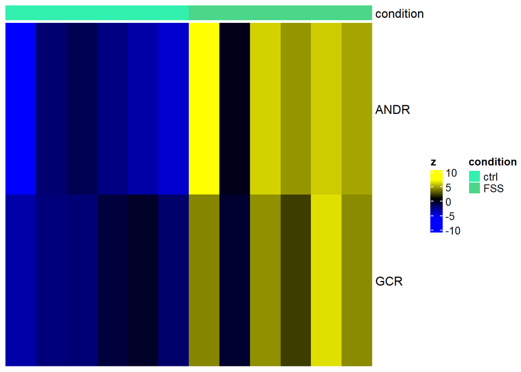

```r
# plot a heatmap of the normalized accessibility scores across the samples for those motifs
# use the 'sechm' function to plot a heatmap of motif accessibility scores
sechm(deviation, features = sig_motifs_ctrl$ID, assayName = "z", top_annotation = "condition")
```

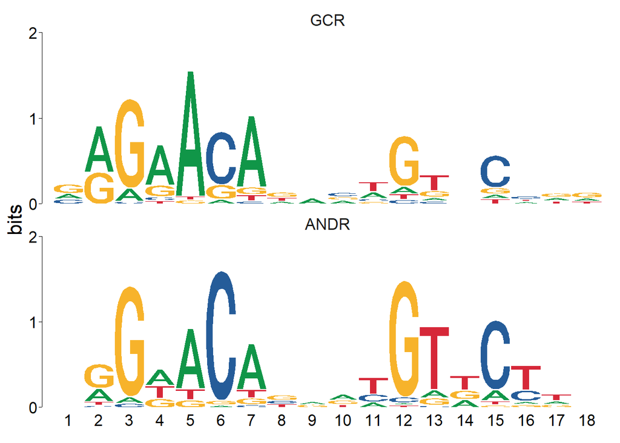

```r
# show the motifs
view_motifs(motifs[c("GCR","ANDR")])
```

#### Interpretation

The motif accessibility for two TFs (GCR, ANDR) was significantly different between stressed (FSS) and control animals. Both TFs have very similar motifs with the high confidence base pairs being identical. This suggests that GCR and ANDR regulate the same genomic sites. Their motifs are more accessible compared to the control. Looking into the functions of those TFs might reveal how they could be linked to stress-response. One out of the six stressed animals did not exhibit the same change in accessibility as the other five. To determine if this is due to variation in the experimental work or due to different stress response of the animal in questions, more experiments would be required.

### comparing male and female animals

```r
deviation$sex
```

```
##  [1] "f" "f" "f" "m" "m" "m" "f" "f" "f" "m" "m" "m"
```

```r
deviation$sex <- factor(deviation$sex)
deviation$sex <- relevel(deviation$sex, "m")
mm_sex <- model.matrix(~deviation$sex)
# equivalent:
#mm_sex <- model.matrix(~sex, data = as.data.frame(colData(deviation)))
mm_sex
```

```
##    (Intercept) deviation$sexf
## 1            1              1
## 2            1              1
## 3            1              1
## 4            1              0
## 5            1              0
## 6            1              0
## 7            1              1
## 8            1              1
## 9            1              1
## 10           1              0
## 11           1              0
## 12           1              0
## attr(,"assign")
## [1] 0 1
## attr(,"contrasts")
## attr(,"contrasts")$`deviation$sex`
## [1] "contr.treatment"
```

```r
# fit a linear model
fit_sex <- eBayes(lmFit(assays(deviation)$z, mm_sex))
fit_sex
```

[output not shown]

[output cut: 82 more lines]

```
##      (Intercept) deviation$sexf
## MUSC  -0.8008451      -1.731570
## AHR   -6.3694501      -6.242623
## AIRE  -5.0293790      -5.590299
## ALX1  -6.2536609      -5.994562
## ANDR  -6.2992421      -6.241496
## 422 more rows ...
##
## $F
## [1] 8.60551129 0.09277308 1.47317182 0.25006803 0.20113260
## 422 more elements ...
##
## $F.p.value
## [1] 0.00350332 0.91194277 0.26189211 0.78207368 0.82007181
## 422 more elements ...
```

```r
# extract results
res_sex <- as.data.frame(topTable(fit_sex, coef="deviation$sexf", number = Inf))
head(res_sex)
```

```
##        ID    logFC    AveExpr         t      P.Value    adj.P.Val         B
## 404  TYY1 9.441078 -0.3436203 10.149358 6.234125e-08 2.661971e-05 8.0703791
## 381 TEAD1 7.811870 -0.1871144  8.342996 7.057124e-07 1.506696e-04 6.0425843
## 331 RUNX3 4.020809 -0.1877905  7.252267 3.662607e-06 5.213111e-04 4.5969761
## 218   MYB 4.106325 -0.5670959  5.938236 3.277082e-05 3.498285e-03 2.6069371
## 425 ZN143 3.956070  0.2438519  4.794492 2.672720e-04 2.111407e-02 0.6524410
## 313 PTF1A 3.053266 -0.3494202  4.739875 2.966848e-04 2.111407e-02 0.5544344
```

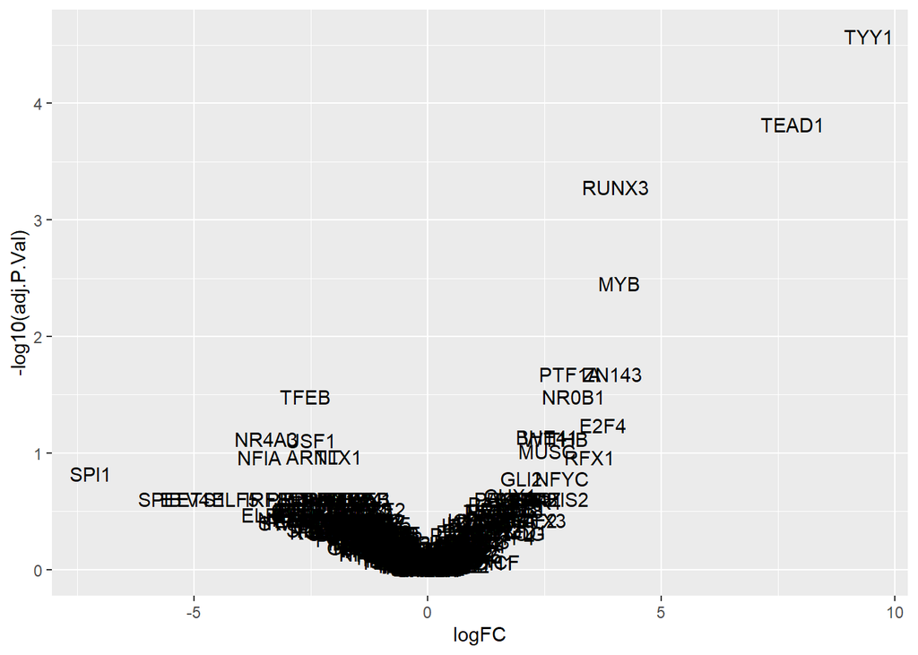

```r
# create a scatter plot
ggplot(res_sex, aes(logFC, -log10(adj.P.Val), label = ID)) + geom_text()
```

```r
# report the top most significant motifs
# Filter motifs based on adjusted p-value <= 0.05
sig_motifs_sex <- res_sex[res_sex$adj.P.Val <= 0.05, ]
print(sig_motifs_sex)
```

```
##        ID     logFC     AveExpr         t      P.Value    adj.P.Val          B
## 404  TYY1  9.441078 -0.34362026 10.149358 6.234125e-08 2.661971e-05  8.0703791
## 381 TEAD1  7.811870 -0.18711444  8.342996 7.057124e-07 1.506696e-04  6.0425843
## 331 RUNX3  4.020809 -0.18779051  7.252267 3.662607e-06 5.213111e-04  4.5969761
## 218   MYB  4.106325 -0.56709593  5.938236 3.277082e-05 3.498285e-03  2.6069371
## 425 ZN143  3.956070  0.24385193  4.794492 2.672720e-04 2.111407e-02  0.6524410
## 313 PTF1A  3.053266 -0.34942019  4.739875 2.966848e-04 2.111407e-02  0.5544344
## 252 NR0B1  3.125448  0.04649938  4.371670 6.049942e-04 3.255151e-02 -0.1155330
## 394  TFEB -2.606641  0.38715692 -4.367569 6.098643e-04 3.255151e-02 -0.1230794
```

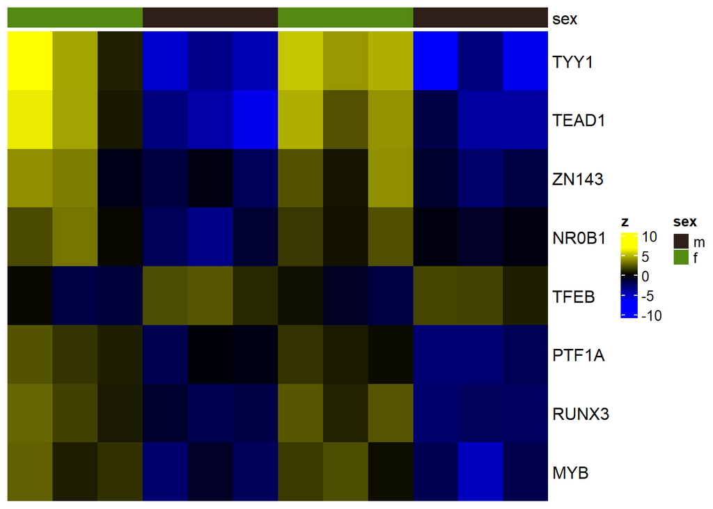

```r
# plot a heatmap of the normalized accessibility scores across the samples for those motifs
# use the 'sechm' function to plot a heatmap of motif accessibility scores
sechm(deviation, features = sig_motifs_sex$ID, assayName = "z", top_annotation = "sex")
```

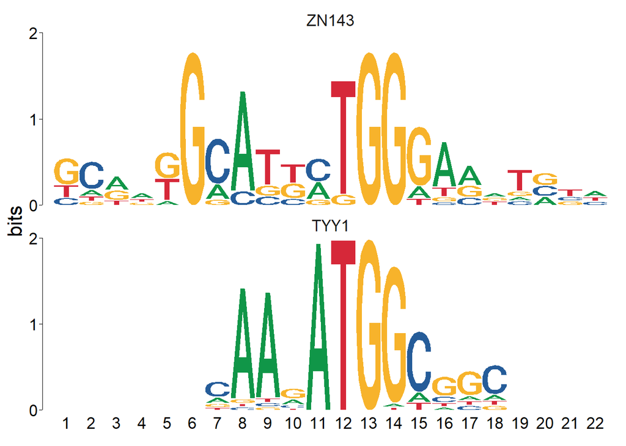

```r
# show the motifs
view_motifs(motifs[c("ZN143", "TYY1")])
```

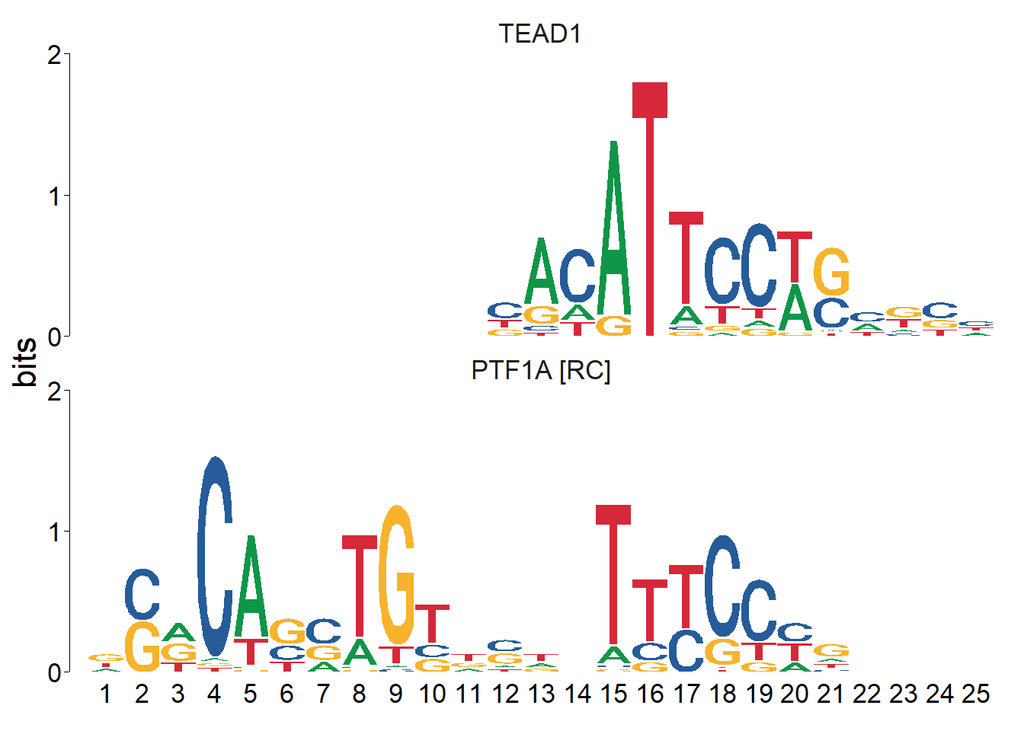

```r
view_motifs(motifs[c("TEAD1", "PTF1A")])
```

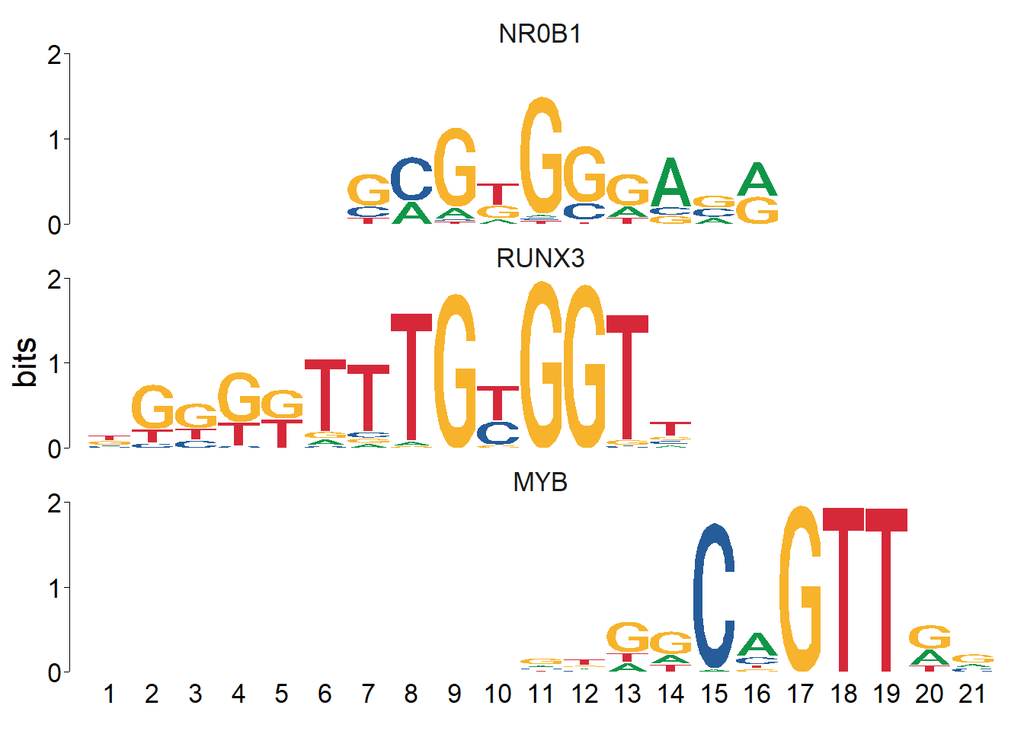

```r
view_motifs(motifs[c("NR0B1", "RUNX3", "MYB")])
```

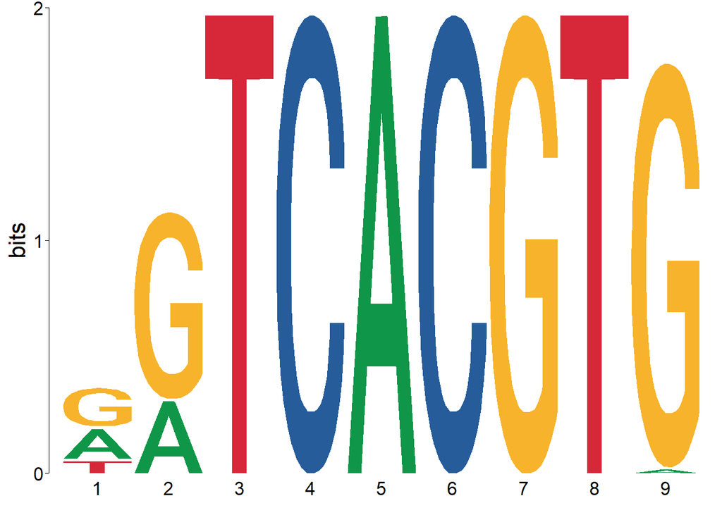

```r
view_motifs(motifs[c("TFEB")])
```

#### Interpretation

Eight TFs are show differential motif accessibility when comparing male and female animals. Of those one shows decreased accessibility in females compared to males and seven show increased accessibility in females compared to males. The motifs for ZN143 and TYY1, the motifs for TEAD1 and PTF1A[RC] and the motifs for NR0B1 and RUNX3 are similar to one another. The motif for MYB does not show and clear resemblance to any of the other six TF that show increased motif accessibility in females over males. The motif for TFEB, the only TF showing decreased motif accessibility in females over males, does not show any resemblance to the motifs of the other TFs. This suggests that the TFs with similar motifs regulate the same genomic sites.